# Spring Term Reading Group, Week 1

Regina Rini and Rachel Barney

Korbinian Friedl

# Regina Rini (2017): “Fake News and Partisan Epistemology”

## Overview of Rini’s paper

1. **Fake news**:
- Definition
- Classification into pure and impure
- Relationship with testimony: concept of *bent testimony*
2. **Partisan Epistemology**
- Her claim: In certain domains, it makes sense to assign greater credibility to a testifier who shares your political affiliation

**Conclusion**: A solution must be institutional, not individual

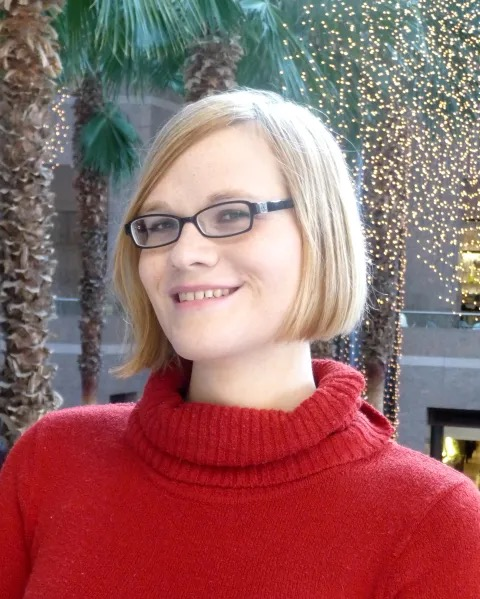

## Part I: Fake News

### What fake news is **not**

- Honest reporting errors (reporter must know the story to be false)
- Private lying (deception must be intended for a larger audience)

### Rini’s definition

> “A fake news story is one that purports to describe events in the real world, typically by mimicking the conventions of traditional media reportage, yet is known by its creators to be significantly false, and is transmitted with the two goals of being widely re-transmitted and of deceiving at least some of its audience.”

(Rini 2017, E–45)

### Pure vs. impure fake news

|  | **Pure** | **Impure** |
| --- | --- | --- |
| Motivation | Epistemic: convince people of claim | Financial: get clicks |
| Examples | Anti-Clinton stories | Macedonian click-farms |
| Deception | the **end** | **instrumental** |

### Fake news and testimony

#### Background: epistemology of testimony

- $A$ believes $p$ on the basis of testimony “when she believes it *because* [it] was presented to her by another person” (Rini 2017, E–46)
- Typically this is an epistemically virtuous practice that allows us to learn a lot more about the world than we otherwise would.
- But there are cases where this default is defeated, based on
  - identity of testifier (e.g., used car salesperson)
  - content of testimony (e.g., radically at odds with what you know about the world)

### Fake news as a *bent* form of testimony

#### Why is “sharing” a story testimony at all?

- Assume I believe that Trump wants to deport Lin-Manuel Miranda because I saw the headline circulating in my Facebook feed.
- “My belief is therefore held on the basis of testimony; I believe it *because* it was presented as truth by another person” (Rini 2017, E–46)

#### How does it differ from “standard” cases of testimony (why is it *bent*)

1. Disputed / unstable norms
   - It is not clear whether sharing a story constitutes *asserting* its content (Rini 2017, E–47) (“Bill, am I going to check every statistic? It was a retweet. It wasn’t from me”)
   - There are *disputed norms* of communication. Social media is new and norms haven’t settled on questions such as:
     - Is a retweet an endorsement?
     - Does posting a news link entail vouching for its truth?
2. The most ridiculous stories get accepted by some people (e.g. Edga Welch believing Pizza gate)
   - “There is something about social media sharing that seems to deaden people’s normal application of consistency-with-the-world filtering on testimony” (E-49)

## Part II: Partisan Epistemology

- Her claim: The testimonial practices propelling fake news are consistent with individual epistemic virtue. In particular:

> “[S]ometimes it makes sense to assign greater credibility to a testifier *because* you know you share a political affiliation with her”

(Rini 2017, E–50)

- When exactly?
- $\rightarrow$ If the testimony pertains to the domain of *politically relevant claims*. This domain comprises
  - Politically normative claims
  - Many morally normative claims
  - Some (seemingly) purely descriptive claims “when these are relevant to political decisions”. Most important among these are “characterological judgments about particular political candidates” (Rini 2017, E–50)

### The argument for partisan epistemology

- What we learn when we learn that $A$ is a fellow partisan (E-51):
  - $A$ share at least some significant number of normative values and beliefs—$A$ “tends to get normative questions right (by my normative lights)”
  - Elga (2007) suggests that, in normative domains, our only epistemic peers are those who agree with us on a broad swath of claims. Partisanship is thus evidence for epistemic peerhood.
- Therefore, on normative claims, it is reasonable to assign fellow partisans higher credibility.
- What about descriptive claims?
  - The act of transmitting political news implicates *normative decisions* about what is *politically important*.
  - “Trusting a testifier regarding political news requires trusting her judgments about political importance” (E-53)

## Part III: Towards a solution of the fake news problem

### Individual solution will not work

- It would have to ask individuals to abandon a locally reasonable practice
- It would impose cognitive cost that individuals are unlikely to pay

### Positive proposal

> “[T]he best place to focus is on institutional arrangements that reduce the bentness of social media testimony.”

(Rini 2017, E–55)

- Realistically the ambiguity can only be resolved in the direction of “sharing counts as endorsing”
- (Though, question for discussion: Why does she now assume that only the two binary resolutions are available when she earlier discussed the more nuanced norms around the newspaper distributor?)

### How to establish her proposed new normativity of sharing

- Social Media corporations cooperate with fact-checkers to classify news stories as “disputed” and “not disputed”, make it harder to share the disputed ones and weigh their algorithms to display them less (E-56–57)
- Problem: This may be too slow. So they should also track the testimonial reputation of individual *users* based on the frequency with which they share the disputed stories and display those scores “in a subtle way” (E-57)

# Rachel Barney (2016): “[Aristotle], *On Trolling*”

## What is a troll?

- One who speaks to a community as if he was a part of it, but really he is opposed to it
- Aims at destroying the good of that community
- Does this by indicating something false without quite saying it and thereby creating strife within the community

## Classification of trolls

- Trolls differ in their motivations
  - Amusement
  - Profit
  - Enmity to the community

## Is there an art of trolling?

- Troll claims to be a gadfly and beneficial
- Like Socrates!
- But he is not like Socrates
  - Socrates was speaking frankly
  - He was annoying, but he was a truth-teller
  - The ἴδιον of the troll is not annoyance, but confusion and strife among a community who really agree

## What gives the trolls such power over blogs, boards and forums

- They are weak communities and their good is easily destroyed
- Everyone knows that “Trolls not to be fed”, but still everyone does it; for the desire to be right on the internet is natural and present to all.

# Discussion

- Is fake news a distinct and pressing problem?
- Is a “share” a form of testimony? If it is, what exactly does the sharing person testify to? And if it is not testimony, what kind of (speech?) act is it?
- Rini says the communication norms around “retweets” and “shares” have not yet settled (E-47). She says this in 2017—have the norms settled some more over the last 9 years? If yes, what are they now?
- Is partisan epistemology good? What are its boundaries?
- What do we think of Rini’s positive proposal? Are there alternative / better forms of holding each other accountable for social media sharing behaviour?
- Is there an art to trolling?

# References

Barney, Rachel. 2016. “[Aristotle], on Trolling.” *Journal of the American Philosophical Association* 2 (2): 193–95. https://doi.org/10.1017/apa.2016.9.

Elga, Adam. 2007. “Reflection and Disagreement.” *Noûs* 41 (3): 478–502.

Rini, Regina. 2017. “Fake News and Partisan Epistemology.” *Kennedy Institute of Ethics Journal* 27 (2 Supplement): E-43-E-64. https://doi.org/10.1353/ken.2017.0025.